RED WINE QUALITY ANALYSIS by Beiran Chen ========================================================

Get known about the dataset structure.

```
## 'data.frame':    1599 obs. of  13 variables:
##  $ X                   : int  1 2 3 4 5 6 7 8 9 10 ...
##  $ fixed.acidity       : num  7.4 7.8 7.8 11.2 7.4 7.4 7.9 7.3 7.8 7.5 ...
##  $ volatile.acidity    : num  0.7 0.88 0.76 0.28 0.7 0.66 0.6 0.65 0.58 0.5 ...
##  $ citric.acid         : num  0 0 0.04 0.56 0 0 0.06 0 0.02 0.36 ...
##  $ residual.sugar      : num  1.9 2.6 2.3 1.9 1.9 1.8 1.6 1.2 2 6.1 ...
##  $ chlorides           : num  0.076 0.098 0.092 0.075 0.076 0.075 0.069 0.065 0.073 0.071 ...
##  $ free.sulfur.dioxide : num  11 25 15 17 11 13 15 15 9 17 ...
##  $ total.sulfur.dioxide: num  34 67 54 60 34 40 59 21 18 102 ...
##  $ density             : num  0.998 0.997 0.997 0.998 0.998 ...
##  $ pH                  : num  3.51 3.2 3.26 3.16 3.51 3.51 3.3 3.39 3.36 3.35 ...
##  $ sulphates           : num  0.56 0.68 0.65 0.58 0.56 0.56 0.46 0.47 0.57 0.8 ...
##  $ alcohol             : num  9.4 9.8 9.8 9.8 9.4 9.4 9.4 10 9.5 10.5 ...
##  $ quality             : int  5 5 5 6 5 5 5 7 7 5 ...
```

This dataset has 1599 objects, and 13 variables. The names of variables:

```
##  [1] "X"                    "fixed.acidity"        "volatile.acidity"
##  [4] "citric.acid"          "residual.sugar"       "chlorides"
##  [7] "free.sulfur.dioxide"  "total.sulfur.dioxide" "density"
## [10] "pH"                   "sulphates"            "alcohol"
## [13] "quality"
```

Description of variables: Ref:(https://s3.amazonaws.com/udacity-hosted-downloads/ud651/wineQualityInfo.txt)

1 - index 2 - fixed acidity (tartaric acid - g / dm^3): most acids involved with wine or fixed or nonvolatile (do not evaporate readily)

3 - volatile acidity (acetic acid - g / dm^3): the amount of acetic acid in wine, which at too high of levels can lead to an unpleasant, vinegar taste

4 - citric acid (g / dm^3): found in small quantities, citric acid can add ‘freshness’ and flavor to wines

5 - residual sugar (g / dm^3): the amount of sugar remaining after fermentation stops, it’s rare to find wines with less than 1 gram/liter and wines with greater than 45 grams/liter are considered sweet

6 - chlorides(sodium chloride - g / dm^3): the amount of salt in the wine

7 - free sulfur dioxide (mg / dm^3): the free form of SO2 exists in equilibrium between molecular SO2 (as a dissolved gas) and bisulfite ion; it prevents microbial growth and the oxidation of wine

8 - total sulfur dioxid (mg / dm^3)e: amount of free and bound forms of S02; in low concentrations, SO2 is mostly undetectable in wine, but at free SO2 concentrations over 50 ppm, SO2 becomes evident in the nose and taste of wine

9 - density (g / cm^3): the density of water is close to that of water depending on the percent alcohol and sugar content

10 - pH: describes how acidic or basic a wine is on a scale from 0 (very acidic) to 14 (very basic); most wines are between 3-4 on the pH scale

11 - sulphates (potassium sulphate - g / dm3): a wine additive which can contribute to sulfur dioxide gas (S02) levels, wich acts as an antimicrobial and antioxidant

12 - alcohol (% by volume): the percent alcohol content of the wine

13 - quality (score between 0 and 10), this is output variable (based on sensory data)

We want to check if there are some missing value

```
##                    X        fixed.acidity     volatile.acidity
##                    0                    0                    0
##          citric.acid       residual.sugar            chlorides
##                    0                    0                    0
##  free.sulfur.dioxide total.sulfur.dioxide              density
##                    0                    0                    0
##                   pH            sulphates              alcohol
##                    0                    0                    0
##              quality
##                    0
```

So there is no missing value.

# Univariate Analysis

At first, we plot every variable distribution histogram:

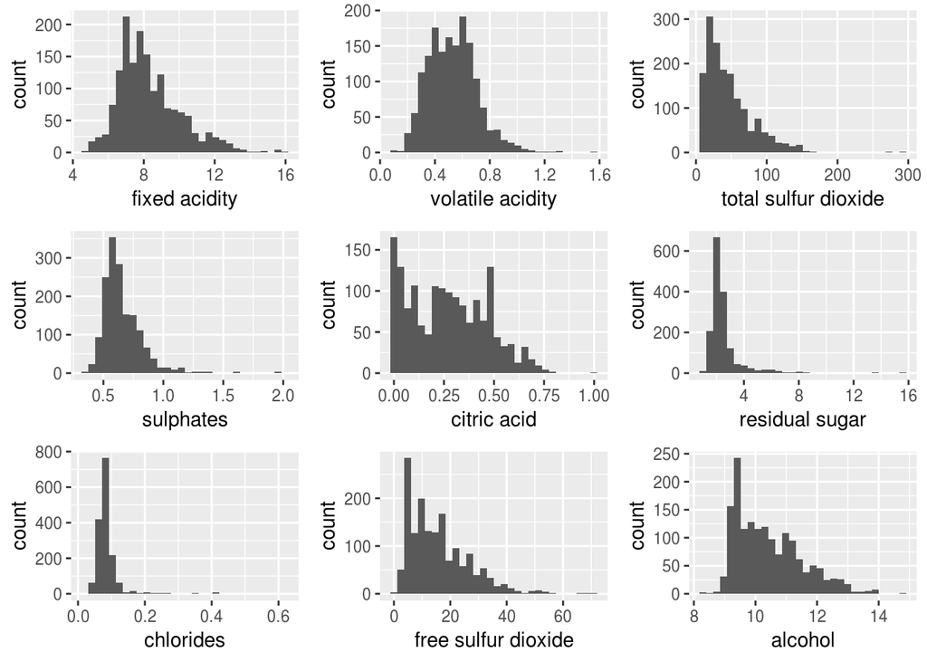

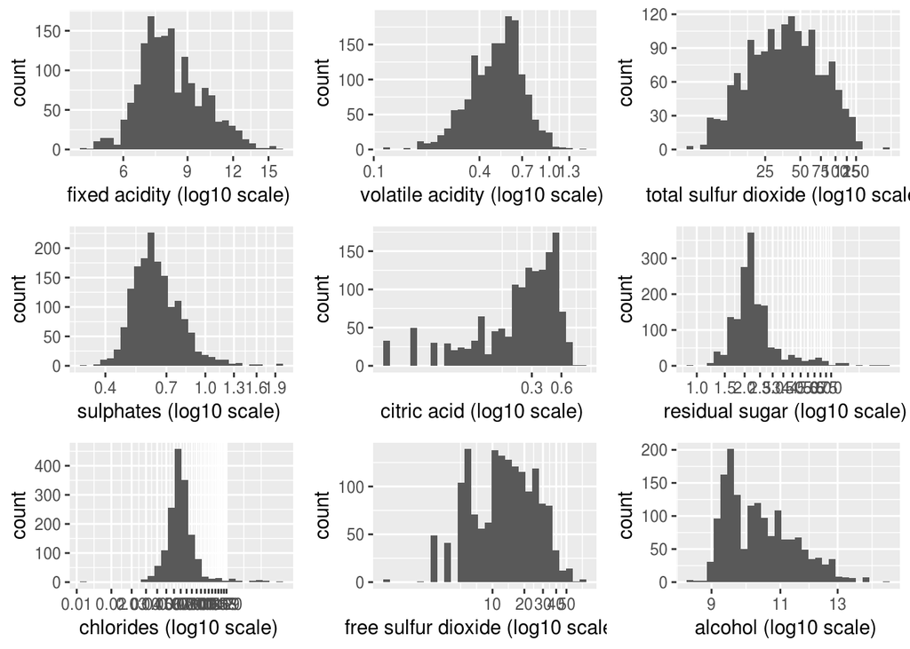

From above plots, after x axis change into log10 scale, we can see the varialbe **fixed.acidity**, **volatile.acidity**, **total.sulfur.dioxide**, and **sulphates** distribution became better, nearly normal distribution.

Check the output variable **quality** summary.

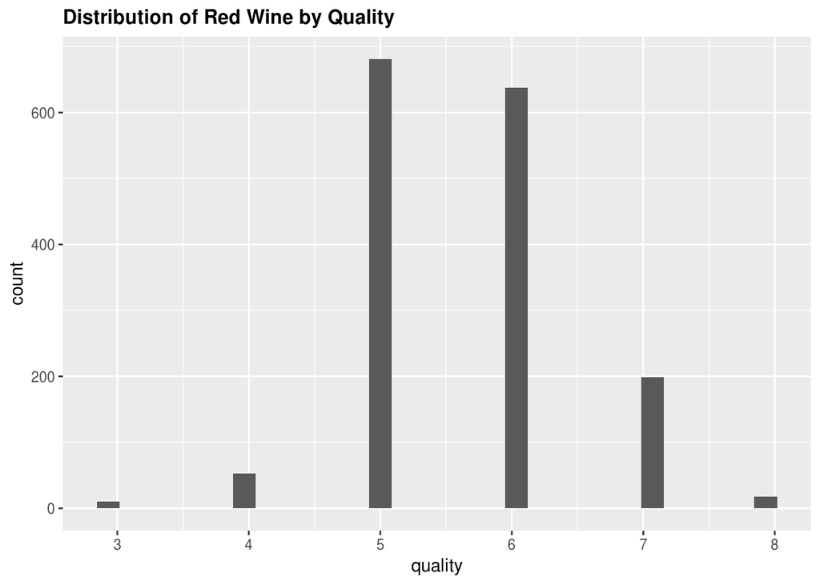

We can see alot of wine value at 5 and 6 . We summary the quality of dataset:

```
##    Min. 1st Qu.  Median    Mean 3rd Qu.    Max.
##   3.000   5.000   6.000   5.636   6.000   8.000
```

```
##                    X        fixed.acidity     volatile.acidity
##                    0                    0                    0
##          citric.acid       residual.sugar            chlorides
##                    0                    0                    0
##  free.sulfur.dioxide total.sulfur.dioxide              density
##                    0                    0                    0
##                   pH            sulphates              alcohol
##                    0                    0                    0
##              quality        quality.level
##                    0                    0
```

We want to know number of wines in each quality level:

```
##     Low Average    Good
##      63    1319     217
```

### What is the structure of your dataset?

The dataset has 1599 obs, 14 variables:

“X” ,“fixed.acidity”, “volatile.acidity”, “citric.acid”, “residual.sugar”, “chlorides”, “free.sulfur.dioxide”, “total.sulfur.dioxide”, “density”, “pH”, “sulphates”, “alcohol”,“quality”,“quality.level”

### What is/are the main feature(s) of interest in your dataset?

In this dataset, the main feature of interest is **quality** of the red wine.

### What other features in the dataset do you think will help support your into your feature(s) of interest?

The Variable **citric.acid**,**pH** seems to be an intersting. We will explore their relationship with **quality** in next bivariate part.

### Did you create any new variables from existing variables in the dataset?

We creare a new variable “quality.level”, which is a category variable.

### Of the features you investigated, were there any unusual distributions? you perform any operations on the data to tidy, adjust, or change the form the data? If so, why did you do this?

I using log10 to scale x axis to reduce the right shew.

# Bivariate Plots Section

We want find out which attributes have strong relationship with **quality** .

```
##                             [,1]
## fixed.acidity         0.12405165
## volatile.acidity     -0.39055778
## citric.acid           0.22637251
## residual.sugar        0.01373164
## chlorides            -0.12890656
## free.sulfur.dioxide  -0.05065606
## total.sulfur.dioxide -0.18510029
## density              -0.17491923
## pH                   -0.05773139
## sulphates             0.25139708
## alcohol               0.47616632
```

From above, we can pick those four attributes which are more relative with quality, their correlation values are:

volatile.acidity -0.3905578

citric.acid 0.2263725

sulphates 0.0.2513971

alcohol 0.4761663

Now we plot those four variables with **quality**.

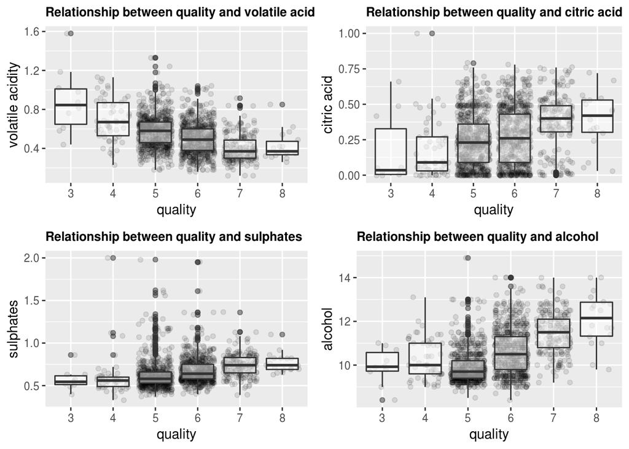

We can see **volatile.acidity** decrease with the increase of output variable **quality**. And **citric.acid**,**sulphates**,**alcohol** increase with the increase of **quality**.

we can also change the plot into **quality.level**.it will show more clear tend.

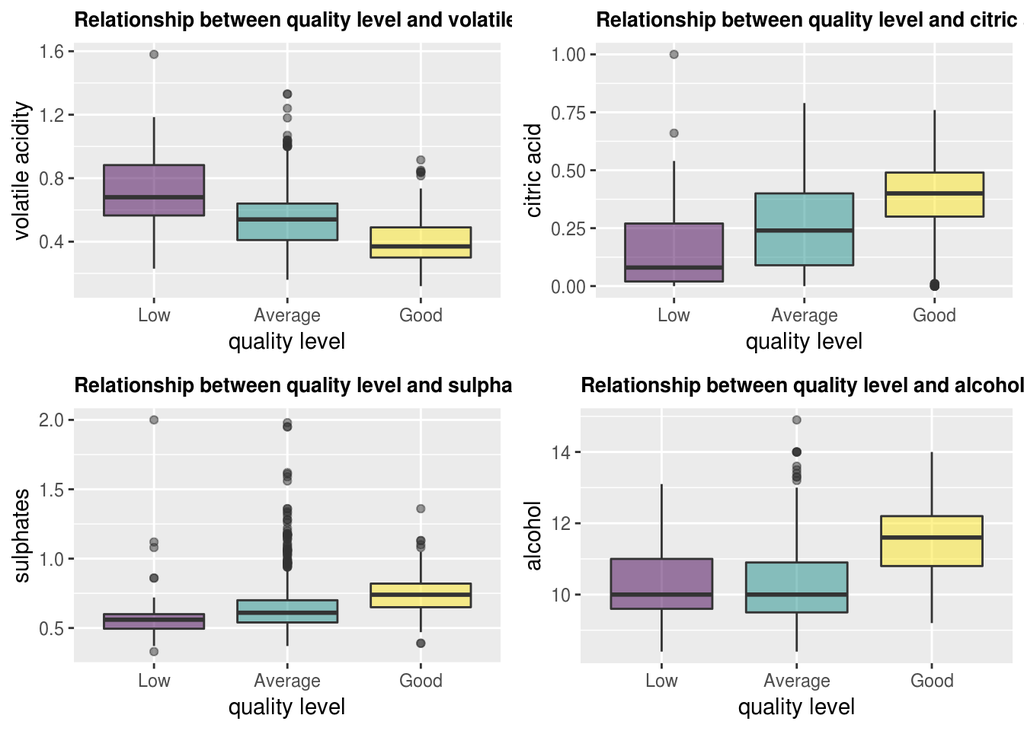

Good quality wine has lower **volatile.acidity**, and higher **citric.acid**,**sulphates**,**alcohol**

Now, We will calculate other variables correlations with each other.

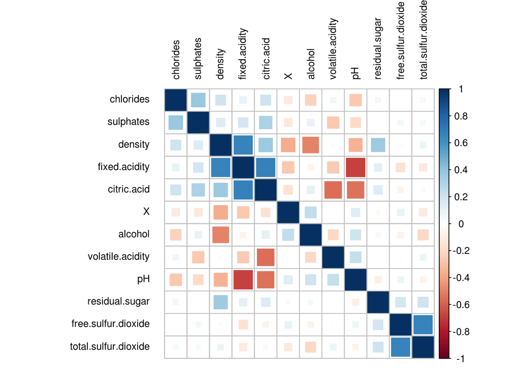

Based on the correlation matrix: **fixed.acidity** is highly positively correlated with **citric.acid** and **density**. **free.sulful.dioxide** is highly positively correlated with**total.sulfur.dioxide** . **fixed.acidity** is highly negatively correlated with**pH** . **citric.acid** is correlated negatively with **volatile.acidity** and **pH**.

We want to pick out four pairs of them to do our further explor:

**1. citric acid~volatile acidity**

Let’s calculate the correlation value:

```
## [1] -0.5524957
```

That means them have strong negative relationship.

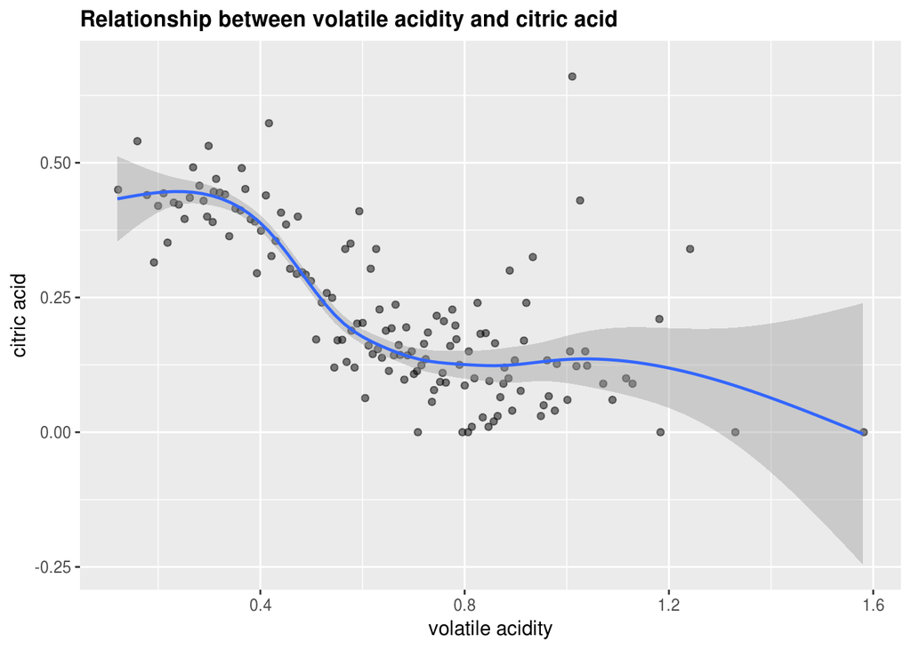

The **citric.acid**decreases with the increasing of **volatile.acidity**, specialiy when the **volatile.acidity** value less than 0.6.

**2. citric acid~pH**

Let’s calculate the correlation value:

```
## [1] -0.5419041
```

That means them have negative relationship.

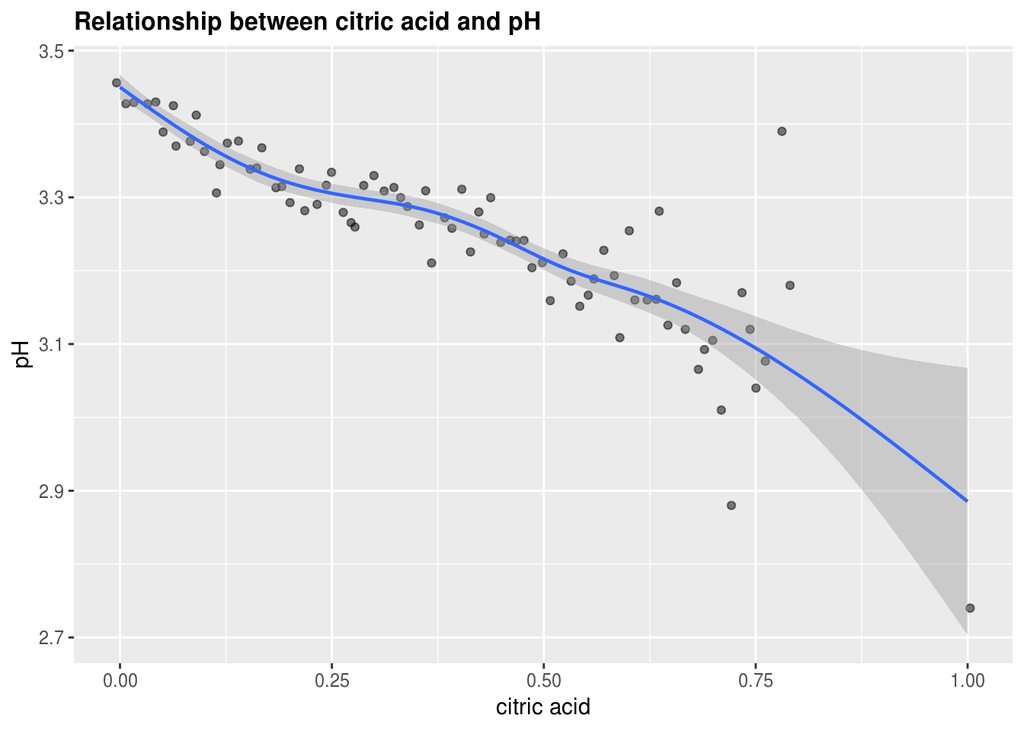

The **pH** attribute grow higher with the decreasing of **citric.acid**.

**3.fixed acidity~density**

Let’s calculate the correlation value:

```
## [1] 0.6680473
```

That means them have positive relationship.

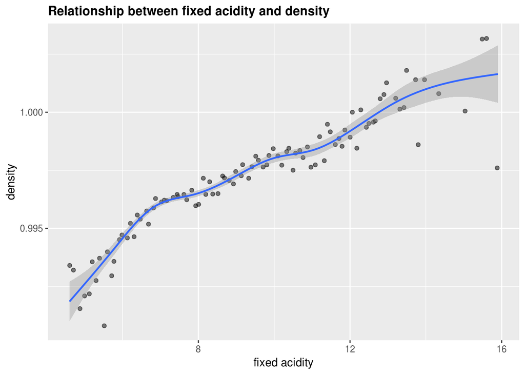

The **fixed.acidity** increases with the increasing of **density**.

**4. fixed acidity~citric acid**

Let’s calculate the correlation value:

```
## [1] 0.6717034
```

That means them have positive relationship.

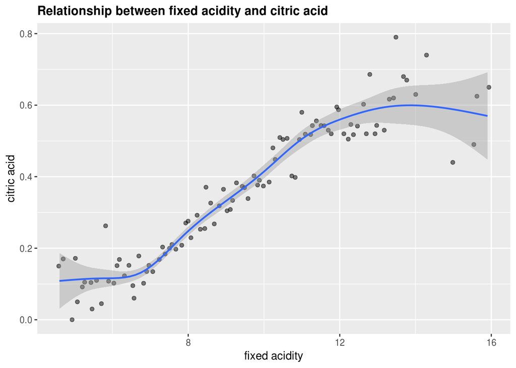

The **citric.acid** increases with the increasing of **fixed.acidity**.

# Bivariate Analysis

### Talk about some of the relationships you observed in this part of the investigation. How did the feature(s) of interest vary with other features in the dataset?

**volatile.acidity** decrease with the increase of output variable **quality**. And **citric.acid**,**sulphates**,**alcohol** increase with the increase of **quality**.

### Did you observe any interesting relationships between the other features (not the main feature(s) of interest)?

1.The **citric.acid**decreases with the increasing of ** volatile.acidity**, specialiy when the** volatile.acidity** value less than 0.6. 2.The **pH** attribute grow higher with the decreasing of **citric.acid**. 3.The **fixed.acidity** increases with the increasing of ** density**. 4.The** citric.acid** increases with the increasing of ** fixed.acidity**.

# Multivariate Plots Section

From last part **Bivariate Analysis**, we explored four pairs variables. Now we want to further explored those four pairs varialbes not only about their relationship between them, but also want to see how the different **quality.level** act in those relationships.

We create some fucntions to help our explor at first.

**1. citric.acid~volatile.acidity with quality.level**

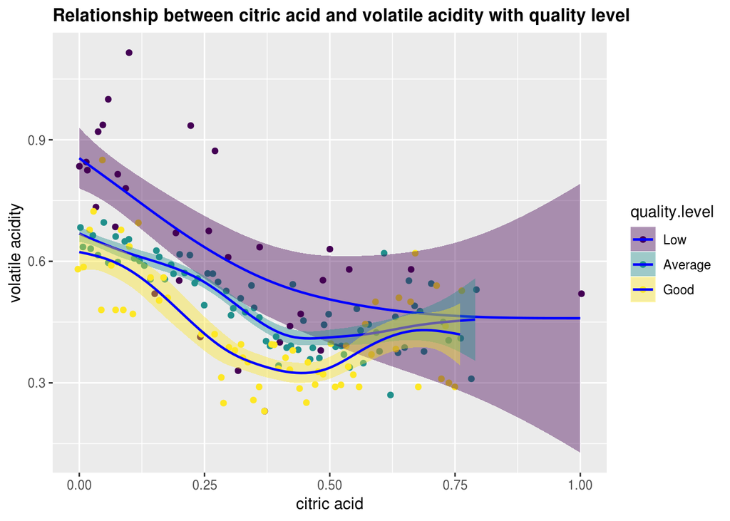

With the increasing of **citric.acid**, Good quality wine has lower **volatile.acidity** value than Average quality wine, and the Low quality wine has higher **volatile.acidity** value than other two. This tendency also can be seen in the boxplot.

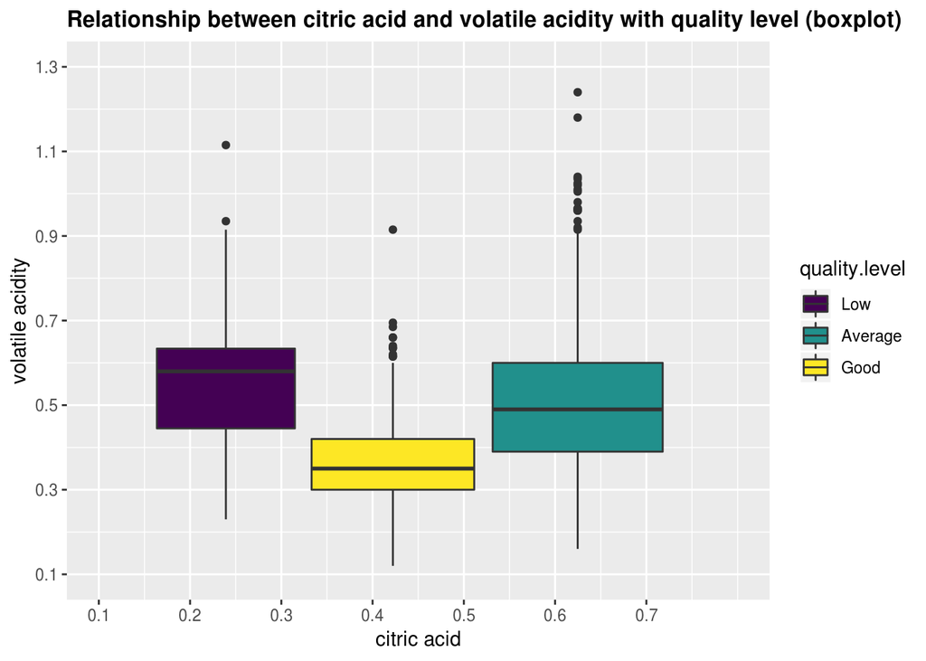

**2. citric.acid~pH with quality.level**

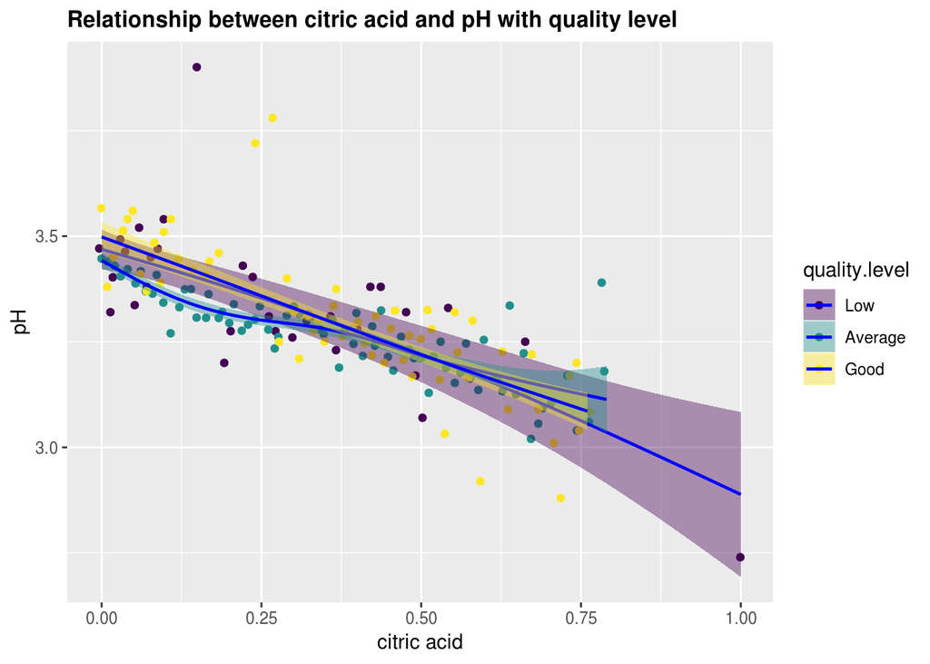

All plots tendency of each quality level very close. We cannot say any quality level is better than other two quality level wine.

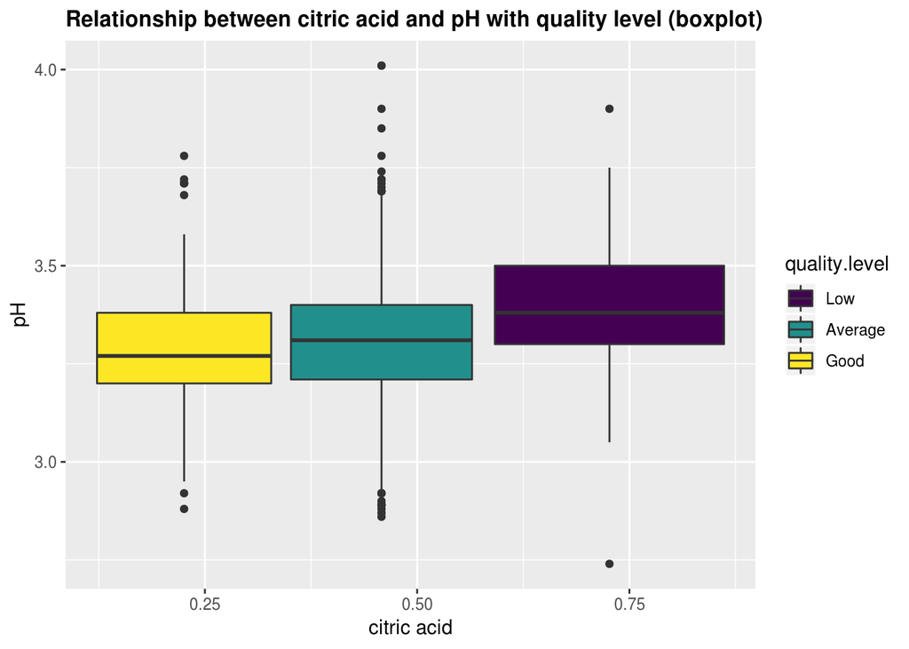

**3.fixed.acidity~density with quality.level**

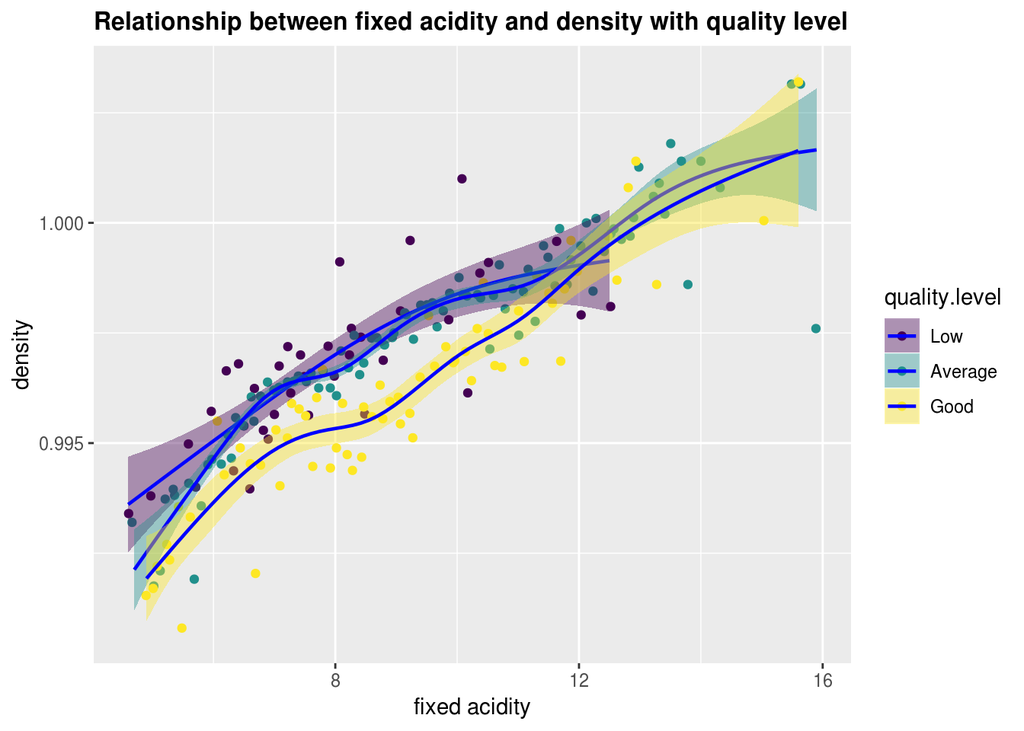

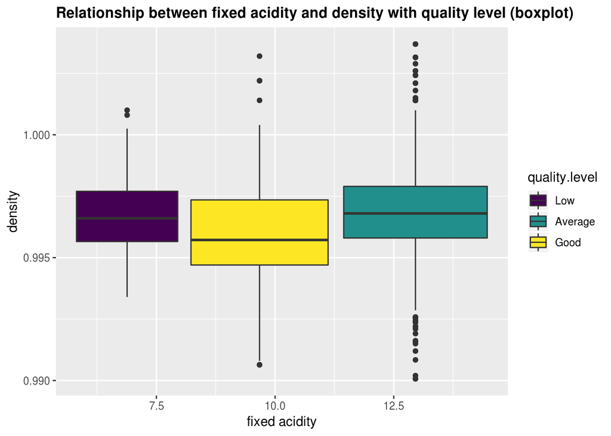

**4. fixed.acidity~citric.acid with quality.level**

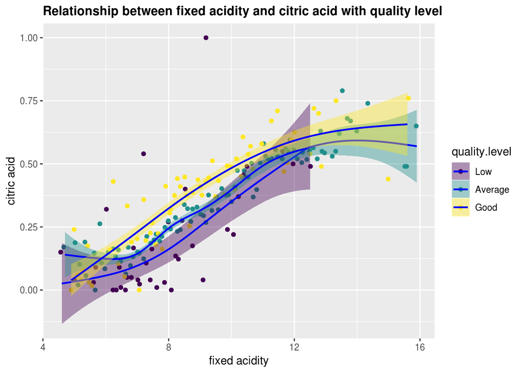

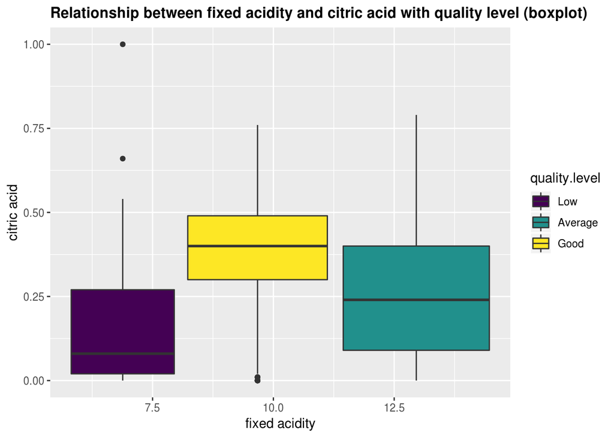

The boxplot above show the same tendency as we explored previously.

# Multivariate Analysis

### Talk about some of the relationships you observed in this part of the investigation. Were there features that strengthened each other in terms of looking at your feature(s) of interest?

1.With the increasing of **citric.acid**, Good quality wine has lower **volatile.acidity** value than Average quality wine, and the Low quality wine has higher **volatile.acidity** value than other two.

### Were there any interesting or surprising interactions between features?

In the secondary relationships we explored (citric.acid~pH), the tendency lines of each quality levels wine very close to each other.

# Final Plots and Summary

We explor red wine quality dataset in this report. The output variable **quality** is the first variable we want to explor.So we plot its distribution. ### Plot One

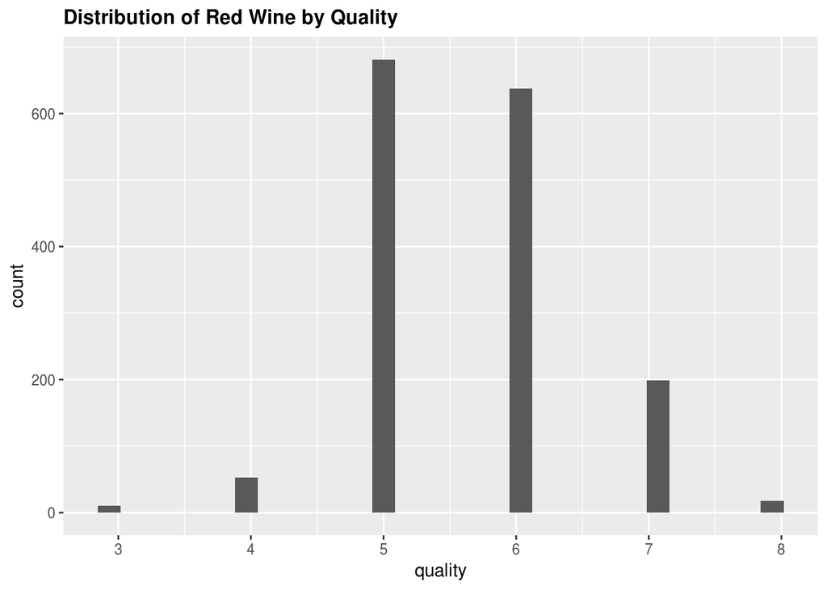

### Description One

This histogram clearly reveals that most red wind is on average rating, and most of these ‘avearge’ red wines have quality value at 5 and 6.

### Plot Two

Because **alcohol** has the highest correlation value with quality, so we want to know their relationship:

Let’s calculate the correlation value:

```
## [1] 0.4761663
```

That means them have positive relationship.

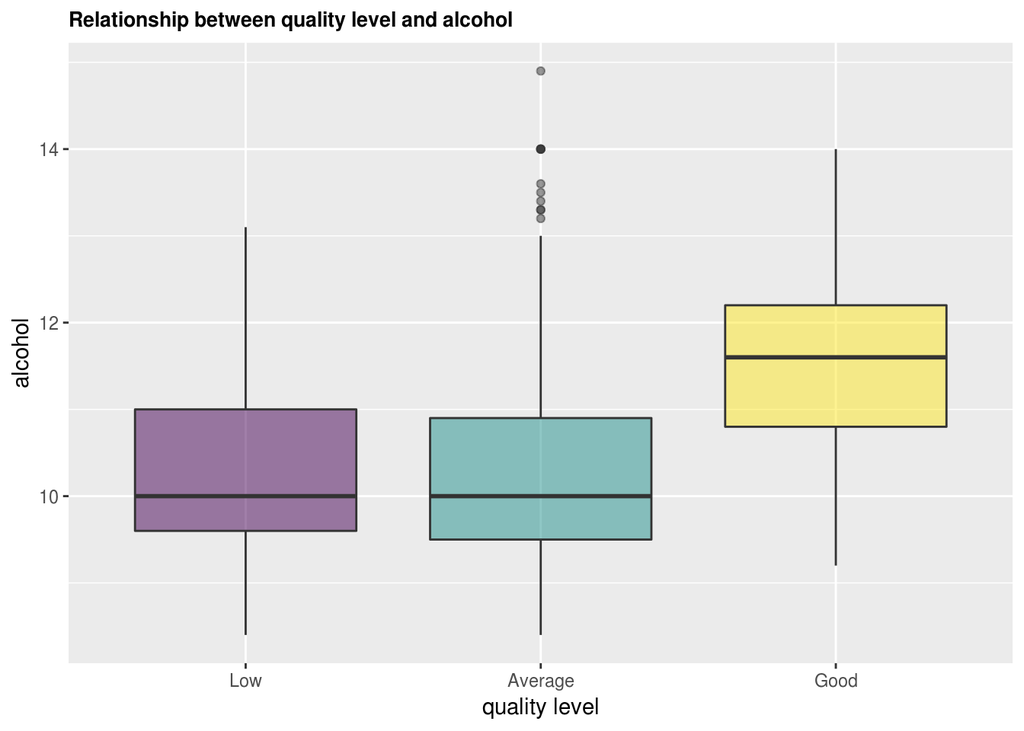

Let’s calculate the correlation value:

```
## [1] 0.6717034
```

That means them have positive relationship.

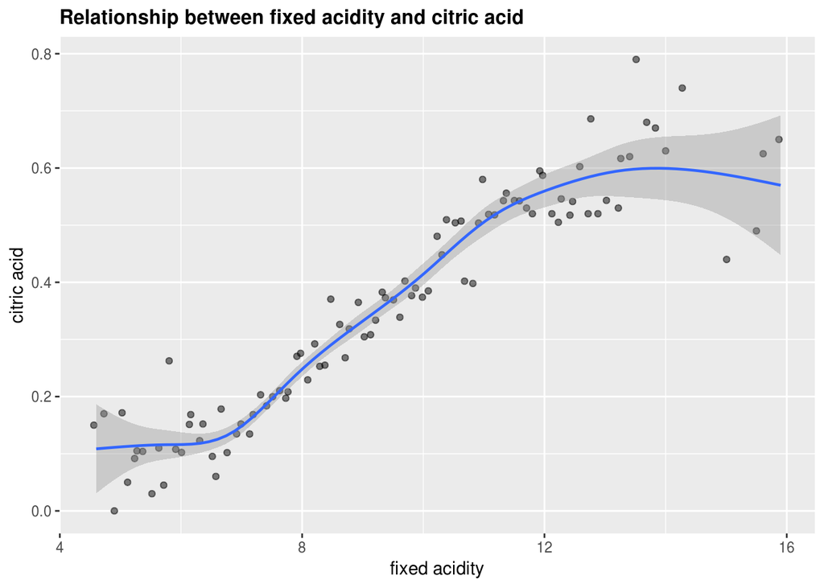

### Description Two

1. The Good wine has high **acohol** than Average and Low quality level wines.
2. The **citric.acid** increases with the increasing of ** fixed.acidity**.

### Plot Three

Now we want to further explored whether the quality of wine has influence on the relationship of **fixed.acidity** and **citric.acid**.

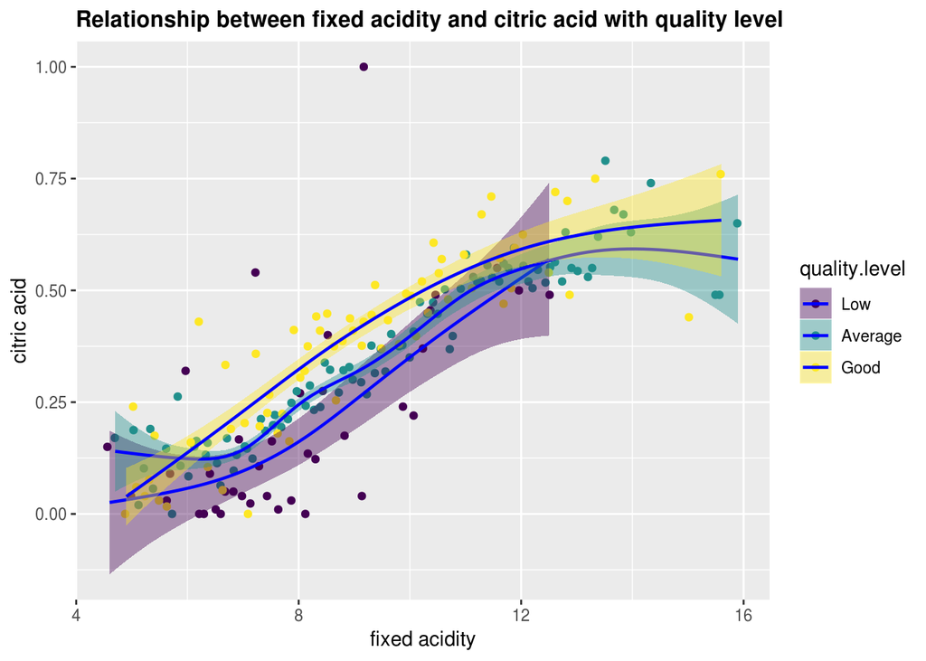

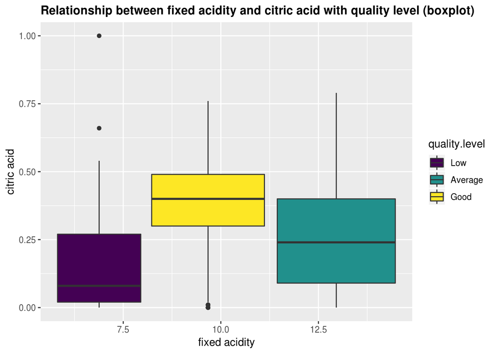

# Reflection

When I began to exploration of this red wine dataset, I want to know the average level of wine quality, and found out most wine at level 5,6. While **volatile.acidity**,**citric.acid** ,**sulphates** and **alcohol** are more relative with quality. I catagory red wine **quality** into three qulity level: Low 3-4 (63 wine samples ), Average 5-6 (1319 wine samples ), Good 7-8 (217 wine samples ).

Because the sample size of Low level wine and Good level wine not enough to predict whether some attribute really have strong effect each other. So, in the futher I hope can get more data to explore those two levels.

Resource:

https://s3.amazonaws.com/udacity-hosted-downloads/ud651/wineQualityInfo.txt

https://cran.r-project.org/web/packages/corrplot/vignettes/corrplot-intro.html

https://stackoverflow.com/questions/7201341/how-can-two-strings-be-concatenated

http://adv-r.had.co.nz/Style.html

https://support.rstudio.com/hc/en-us/articles/200549016-Customizing-RStudio#editing

http://www.cookbook-r.com/Graphs/Legends_(ggplot2)/